# **PCFL 2023: Week 11 wrap-up**

Week 11 is a wrap. Just four weeks left in the regular season!

While this hasn’t been Brian’s best PCFL season, you should keep him all in your thoughts and prayers this week. He’s in the championship game for our guillotine league.

## Last week’s games

| Winner | Winner’s score | Loser | Loser’s score |
| --- | --- | --- | --- |
| Middle Earth Hangry Hobbits | 115.96 | Georgia Peanuts | 101.54 |
| The Seniors | 114.90 | Southern Sharks | 94.94 |
| The G.O.A.T. | 110.00 | Captain Clairvoyant | 99.90 |
| KC Gophers | 108.78 | Jumpin’ Jaheims | 105.10 |
| Pigskin on the Gridiron | 110.66 | Athens Team Sasquatch | 109.34 |

Kind of a low scoring week this week, but bye weeks will do that to you. Scott led the way with 115 points, and no one did especially poorly.

## Best performances

### Best players overall

Here’s last week’s **10 best performing starters.**

| Player | Position | NFL Team | Points | PCFL Team |
| --- | --- | --- | --- | --- |
| Saquon Barkley | RB | NYG | 28.00 | Middle Earth Hangry Hobbits |
| Calvin Ridley | WR | JAC | 27.60 | The G.O.A.T. |
| Tank Dell | WR | HOU | 25.90 | Athens Team Sasquatch |
| Justin Herbert | QB | LAC | 25.70 | Jumpin’ Jaheims |
| Tyreek Hill | RB/WR/TE | MIA | 25.60 | Athens Team Sasquatch |
| Brandon Aiyuk | RB/WR/TE | SFO | 25.10 | Georgia Peanuts |
| Lamar Jackson | QB | BAL | 23.96 | Middle Earth Hangry Hobbits |
| Cowboys D/ST | DST | DAL | 23.00 | Pigskin on the Gridiron |
| Keenan Allen | WR | LAC | 22.60 | Pigskin on the Gridiron |
| Josh Allen | QB | BUF | 22.50 | The G.O.A.T. |

I still think Tank Dell is such a great football name, and the Texans are having a nice season overall.

### Best players per team

Here’s last week’s top players **on each team.**

| Player | Position | NFL Team | Points | PCFL Team |
| --- | --- | --- | --- | --- |
| Tank Dell | WR | HOU | 25.90 | Athens Team Sasquatch |
| Trevor Lawrence | BE | JAC | 32.18 | Captain Clairvoyant |
| Brandon Aiyuk | RB/WR/TE | SFO | 25.10 | Georgia Peanuts |
| Justin Herbert | QB | LAC | 25.70 | Jumpin’ Jaheims |
| DJ Moore | WR | CHI | 19.10 | KC Gophers |
| Saquon Barkley | RB | NYG | 28.00 | Middle Earth Hangry Hobbits |
| Cowboys D/ST | DST | DAL | 23.00 | Pigskin on the Gridiron |
| James Cook | RB/WR/TE | BUF | 17.70 | Southern Sharks |
| Calvin Ridley | WR | JAC | 27.60 | The G.O.A.T. |
| Jalen Hurts | QB | PHI | 18.90 | The Seniors |

### Best bench

Who won the **best scoring bench** award last week?

| Team | Bench points |
| --- | --- |
| Jumpin’ Jaheims | 74.84 |
| Georgia Peanuts | 65.86 |
| The G.O.A.T. | 65.67 |
| Middle Earth Hangry Hobbits | 64.62 |
| Pigskin on the Gridiron | 53.76 |
| Captain Clairvoyant | 50.38 |
| Athens Team Sasquatch | 40.10 |
| KC Gophers | 33.70 |
| Southern Sharks | 31.54 |
| The Seniors | 18.60 |

Here’s the season’s bench standings:

| Team | Bench points |
| --- | --- |
| Georgia Peanuts | 737.20 |
| Jumpin’ Jaheims | 667.84 |
| Middle Earth Hangry Hobbits | 606.09 |
| Athens Team Sasquatch | 605.36 |
| Pigskin on the Gridiron | 574.81 |
| Southern Sharks | 562.66 |
| Captain Clairvoyant | 552.80 |
| The G.O.A.T. | 552.53 |
| The Seniors | 521.34 |
| KC Gophers | 483.10 |

I’ve got the end zone in sight! Just hope there’s enough gas in the tank to get over the goal line.

### Best optimized lineups

I compared the actual starting lineups for each team to the hypothetical *best* starting lineup the owner could have started. The table below shows the actual points the team scored, the top score they could have had, and an “optimization” percentage that compares to the two.

| PCFL Team | Actual points | Best lineup | Optimization rate |
| --- | --- | --- | --- |
| Middle Earth Hangry Hobbits | 115.96 | 116.76 | 99% |
| The Seniors | 114.90 | 118.40 | 97% |
| Southern Sharks | 94.94 | 102.04 | 93% |
| Athens Team Sasquatch | 109.34 | 119.30 | 92% |
| KC Gophers | 108.78 | 118.98 | 91% |
| Captain Clairvoyant | 99.90 | 120.08 | 83% |
| Pigskin on the Gridiron | 110.66 | 132.96 | 83% |
| The G.O.A.T. | 110.00 | 133.47 | 82% |
| Jumpin’ Jaheims | 105.10 | 131.30 | 80% |
| Georgia Peanuts | 101.54 | 133.96 | 76% |

Rough week for my Peanuts.

For the *whole season*, here’s a graph of actual points scored vs. optimized points given the roster.

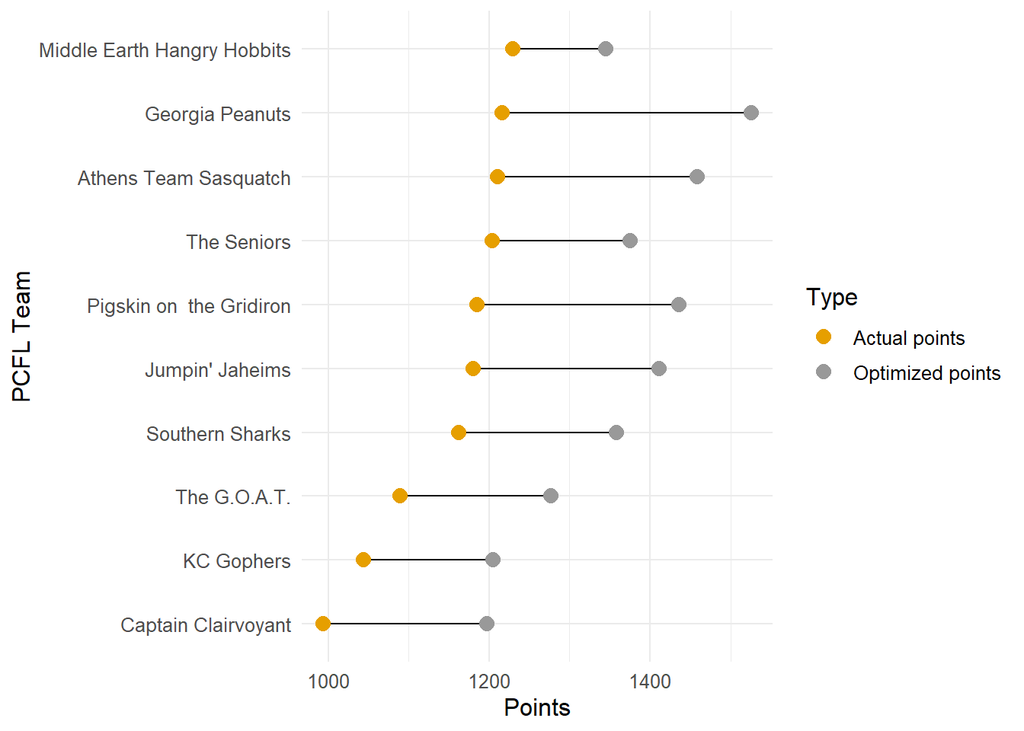

The Hobbits inching into first on points scored, and with a very efficient use of players.

### Point distribution by position

Here’s a breakdown of point contribution by position by team so far this season.

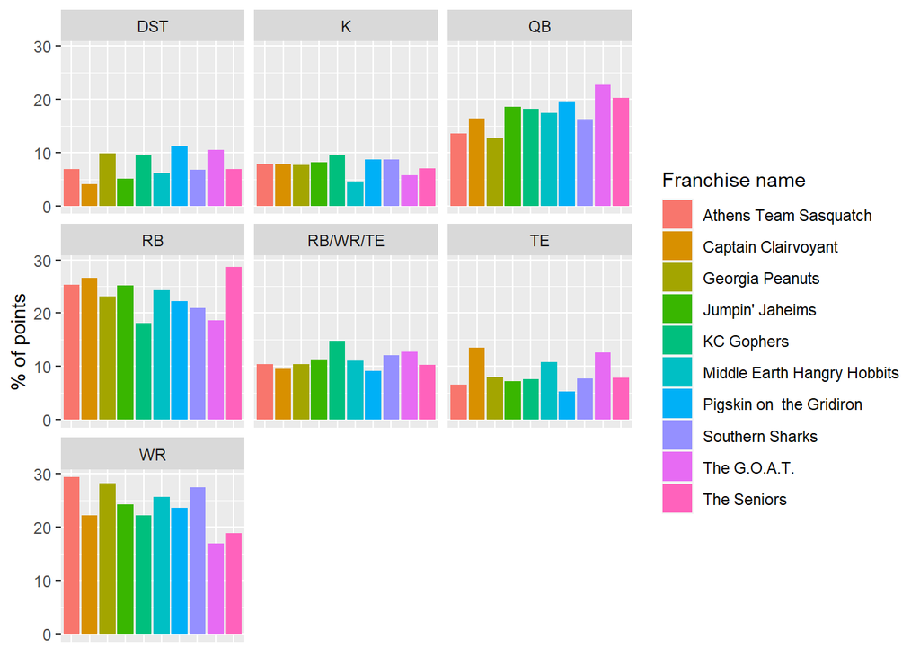

Fun facts for the week:

- With a solid week, Brian’s DST is finally up over 40 points. By comparison, Richard’s first with *133*.
- In contrast, Brian’s TE group has scored 135 points, second only to Jacob (138). Here, Richard is LAST with just 62.
- WRs still are the highest scoring bunch, 4 out of the 5 top scoring units. The leader here is Robbie (355).

### Best pick-ups

There were 13 players added last week. Which was the **best pick-ups**?

| PCFL Team | Player | NFL Team | Position | Points |
| --- | --- | --- | --- | --- |
| KC Gophers | Devin Singletary | HOU | RB | 18.8 |
| Pigskin on the Gridiron | Ty Chandler | MIN | RB | 13.0 |
| Captain Clairvoyant | 49ers D/ST | SFO | DST | 11.0 |
| Captain Clairvoyant | Elijah Moore | CLE | WR | 9.0 |
| Jumpin’ Jaheims | Jake Moody | SFO | K | 9.0 |
| KC Gophers | Cameron Dicker | LAC | K | 8.0 |
| Jumpin’ Jaheims | Texans D/ST | HOU | DST | 8.0 |
| Middle Earth Hangry Hobbits | Royce Freeman | LAR | RB | 7.3 |
| Athens Team Sasquatch | Lions D/ST | DET | DST | 6.0 |
| The Seniors | Vikings D/ST | MIN | DST | 4.0 |
| The Seniors | Riley Patterson | DET | K | 3.0 |
| Georgia Peanuts | Noah Brown | HOU | WR | 0.0 |
| Captain Clairvoyant | Antonio Gibson | WAS | RB | 0.0 |

A couple of nice RB pickups, but otherwise a little underwhelming.

### Best team performances

Here’s a list of the **top five scoring performances** so far this season.

| PCFL Team | Week | Score | Result |
| --- | --- | --- | --- |
| Athens Team Sasquatch | 8 | 180.02 | W |
| Middle Earth Hangry Hobbits | 2 | 167.18 | W |
| Jumpin’ Jaheims | 4 | 149.98 | W |
| Georgia Peanuts | 4 | 148.64 | W |
| The Seniors | 3 | 146.88 | W |

No changes this week, and really not much since week 4.

## Looking ahead

### League standings

| PCFL Team | Division | Points scored | Avg points | Avg last 3 | W | L | Team points |
| --- | --- | --- | --- | --- | --- | --- | --- |
| Middle Earth Hangry Hobbits | Hot Dish | 1229.22 | 111.75 | 112.75 | 7 | 4 | 15 |
| Georgia Peanuts | Hot Dish | 1216.24 | 110.57 | 99.24 | 6 | 5 | 13 |
| Pigskin on the Gridiron | Grits | 1178.14 | 107.10 | 111.56 | 7 | 4 | 13 |
| Athens Team Sasquatch | Grits | 1210.68 | 110.06 | 93.01 | 6 | 5 | 12 |
| The Seniors | Hot Dish | 1203.95 | 109.45 | 101.67 | 5 | 6 | 12 |
| Southern Sharks | Hot Dish | 1162.01 | 105.64 | 107.04 | 5 | 6 | 12 |
| The G.O.A.T. | Grits | 1089.25 | 99.02 | 112.73 | 6 | 5 | 11 |
| Jumpin’ Jaheims | Grits | 1180.00 | 107.27 | 109.05 | 5 | 6 | 10 |
| KC Gophers | Hot Dish | 1034.86 | 94.08 | 91.36 | 4 | 7 | 7 |
| Captain Clairvoyant | Grits | 993.48 | 90.32 | 85.50 | 4 | 7 | 5 |

Scott’s taken control! There’s also a logjam for 4th-6th place between Robbie, Erin/Trav, and Sarah.

### If the season ended today…

Playoffs currently stand as Scott, me, Richard, and Robbie (tiebreaker is total points).

### This week’s matchups

| Team 1 | Team 2 |
| --- | --- |
| Athens Team Sasquatch (Avg. last 3: 93.01) | The G.O.A.T. (Avg. last 3: 112.73) |
| Captain Clairvoyant (Avg. last 3: 85.5) | Jumpin’ Jaheims (Avg. last 3: 109.05) |
| Georgia Peanuts (Avg. last 3: 99.24) | Southern Sharks (Avg. last 3: 107.04) |
| KC Gophers (Avg. last 3: 91.36) | The Seniors (Avg. last 3: 101.67) |
| Middle Earth Hangry Hobbits (Avg. last 3: 112.75) | Pigskin on the Gridiron (Avg. last 3: 111.56) |

We’ll see if Richard can knock Scott out of first, and Jacob has the task of dethroning Robbie this week.

Good luck, y’all!